# EP07 - Equipo 9

N - N

2025-12-01

```r
# datos
datos <- read.csv("EP07 Datos.csv", stringsAsFactors = FALSE)
```

## Pregunta 1: Observando los datos, la memorista sospecha que hay diferencias significativas en el tiempo de ejecución entre las versiones A y B del algoritmo cuando las instancias tienen 45 o más nodos. ¿Los datos respaldan la intuición de la memorista?

Para responder, filtren los datos para tener las instancias con 45 o más nodos y seleccionen las columnas de los tiempos de ejecución de las versiones A y B en formato ancho. Usando como semilla el valor 71, obtenga muestras aleatorias independientes de 23 tiempos registrados por la versión A y 22 tiempos registrados por la versión B del algoritmo. Realicen un análisis estadístico pertinente (enunciar hipótesis, revisar condiciones, seleccionar pruebas ómnibus y post-hoc según corresponda) para responder la pregunta planteada, utilizando pruebas no paramétricas de ser necesario.

Antes de pasar a la formulación de las hipótesis, es necesario filtrar los datos y aplicar los procedimientos requeridos por la pregunta. En primer lugar se filtran los datos de los algoritmos A y B con más de 45 nodos.

```r
# Se filtran instancias con 45 o más nodos

datos_filtrados <- datos %>%
  filter(n.nodos >= 45) %>%
  select(tiempo.A, tiempo.B)
```

Posteriormente se determina la semilla como 71 y se escogen 23 datos de la muestra A y 22 datos de la muestra B.

```r
set.seed(71)

muestra_A <- sample(datos_filtrados$tiempo.A, 23, replace = TRUE)
muestra_B <- sample(datos_filtrados$tiempo.B, 22, replace = TRUE)
```

## Hipótesis pregunta 1

H_0: Los tiempos de ejecución entre las versiones A y B del algoritmo cuando las instancias tienen 45 o más nodos no tienen diferencias significativas.

H_A: Los tiempo de ejecución entre las versiones A y B del algoritmo cuando las instancias tienen 45 o más nodos tienen diferencias significativas.

Las hipótesis están establecidas, pero primero se necesita corroborar la prueba omnibus que hay que utilizar. Como son menos de 30 datos será complicado aplicar una prueba paramétrica, pero aún así se realizan pruebas de normalidad y se hace un Gráfico Q-Q para consolidar la decisión de la prueba.

```r
shapiro.test(muestra_A)
```

```
##
##  Shapiro-Wilk normality test
##
## data:  muestra_A
## W = 0.86665, p-value = 0.005535
```

```r
shapiro.test(muestra_B)
```

```
##
##  Shapiro-Wilk normality test
##
## data:  muestra_B
## W = 0.93959, p-value = 0.1941
```

Los resultados de las pruebas de normalidad indican que la muestra A no sigue una distribución normal mientras que la muestra B si lo hace. A continuación se realiza un gráfico Q-Q para ver visualmente los resultados.

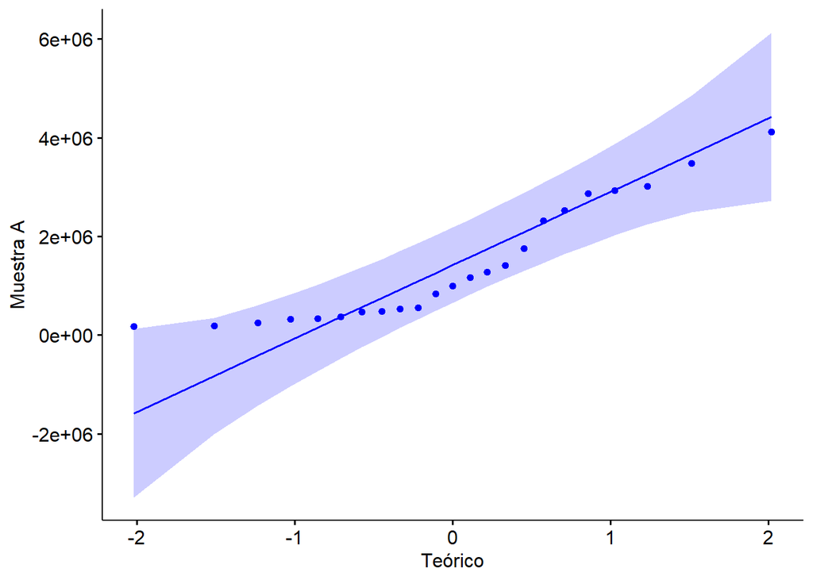

```r
#Gráfico Q-Q para normalidad
g1 <- ggqqplot(data = muestra_A,
                    xlab = "Teórico",
                    ylab = "Muestra A",
                    color = "blue",
                    alpha = 0.7)

g2 <- ggqqplot(data = muestra_B,
                    xlab = "Teórico",
                    ylab = "Muestra B",
                    color = "red",
                    alpha = 0.7)
print(g1)
```

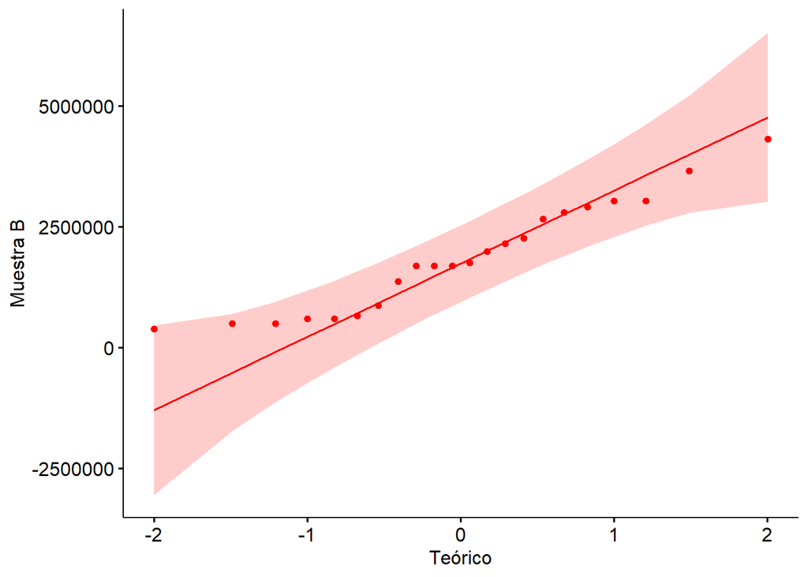

```r
print(g2)
```

Como se puede evidenciar la muestra B tiene puntos que tienden más a una distribución normal que la muestra A, no obstante, como la muestra A no sigue normalidad, no se puede utilizar una prueba paramétrica. Además de que ambas muestras son independientes. Por todo esto se decide utilizar una prueba no paramétrica para dos muestras. Específicamente se emplea la prueba no paramétrica de Mann-Whitney-Wilcoxon.

```r
wilcox.test(muestra_A, muestra_B, alternative = "two.sided")
```

```
##
##  Wilcoxon rank sum test with continuity correction
##
## data:  muestra_A and muestra_B
## W = 179, p-value = 0.09508
## alternative hypothesis: true location shift is not equal to 0
```

El valor p obtenido es de 0.095, el cual si bien es mayor al valor p estándar de esta prueba de 0.05, es un valor bastante cercano, por lo cual se calcula la potencia de la prueba estadística.

```r
cohen.d(muestra_A, muestra_B)
```

```
##
## Cohen's d
##
## d estimate: -0.3960177 (small)
## 95 percent confidence interval:
##      lower      upper
## -1.0032911  0.2112557
```

```r
d <- abs(cohen.d(muestra_A, muestra_B)$estimate)

pwr.t2n.test(n1 = 23, n2 = 22, d = d, sig.level = 0.05, power = NULL, alternative = "two.sided")
```

```
##
##      t test power calculation
##
##              n1 = 23
##              n2 = 22
##               d = 0.3960177
##       sig.level = 0.05
##           power = 0.2546813
##     alternative = two.sided
```

Como se puede ver el poder estadístico de es 0.25, lo que nos lleva a la conclusión se que si bien no se rechaza la hipótesis nula, su potencia es solo del 25%.

Concluyendo, se compararon los tiempos de ejecución de las versiones A y B del algoritmo en instancias con 45 o más nodos utilizando la prueba no paramétrica de Mann‑Whitney‑Wilcoxon, dado que la muestra A no sigue normalidad y los tamaños de ambas muestras son pequeños. El test arrojó un p-valor aproximado = 0.095 debido a la existencia de empates en los datos, lo cual es estadísticamente válido bajo la implementación estándar del test en R. Además, se determinó que el estudio tiene baja potencia estadística (0.25), es decir, solo un 25% de probabilidad de detectar una diferencia real en caso de existir.

Como el p-valor es mayor que 0.05, no se rechaza la hipótesis nula (H₀) al nivel de significancia del 5%, por lo que no hay evidencia suficiente para afirmar que exista una diferencia significativa entre A y B.

Sin embargo, la baja potencia indica que la prueba tiene capacidad limitada para detectar diferencias, por lo que no se puede descartar con certeza que una diferencia real exista. Se recomienda interpretar este resultado como exploratorio y considerar un estudio posterior con un mayor número de observaciones para obtener una conclusión más concluyente.

## Pregunta 2: La memorista también sospecha que, al comparar las mismas instancias de iguales características, las mejores soluciones encontradas por las versiones A y C tienen rendimientos distintos. ¿Estará en lo cierto?

Para responder, filtren los datos para tener las instancias con 45 o más nodos y seleccionen las columnas con el mejor rendimiento de las versiones A y C en formato ancho. Usando como semilla el valor 54, obtengan una muestra aleatoria de 20 instancias. Realicen un análisis estadístico pertinente (enunciar hipótesis, revisar condiciones, seleccionar pruebas ómnibus y post-hoc según corresponda) para responder la pregunta planteada, utilizando pruebas no paramétricas de ser necesario.

En primer lugar se parte filtrando los datos para tener las instancias con más de 45 nodos de los algoritmos A y C

```r
# Se filtran instancias con 45 o más nodos con mejor rendimiento

datos_filtrados2 <- datos %>%
  filter(n.nodos >= 45) %>%
  select(mejor.A, mejor.C)
```

Posteriormente se determina la semilla como 54 y se escogen 20 datos de cada muestra.

```r
set.seed(54)

muestra_A <- sample(datos_filtrados2$mejor.A, 20, replace = TRUE) #Se sobreescribe la variable muestra_A
muestra_C <- sample(datos_filtrados2$mejor.C, 20, replace = TRUE)
```

## Hipótesis pregunta 2

H_0: Las mejores soluciones encontradas por las versiones A y C del algoritmo cuando las instancias tienen 45 o más nodos no tienen diferencias significativas.

```r
shapiro.test(muestra_A)
```

```
##
##  Shapiro-Wilk normality test
##
## data:  muestra_A
## W = 0.87656, p-value = 0.01535
```

```r
shapiro.test(muestra_C)
```

```
##
##  Shapiro-Wilk normality test
##
## data:  muestra_C
## W = 0.88291, p-value = 0.01996
```

Los resultados de las pruebas de normalidad indican que ni la muestra A ni la muestra C presentan normalidad, de todas formas se grafican ambas muestras para comprobar este hecho.

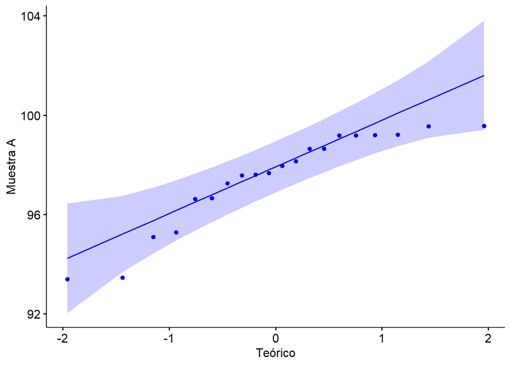

```r
#Gráfico Q-Q para normalidad
g3 <- ggqqplot(data = muestra_A,
                    xlab = "Teórico",
                    ylab = "Muestra A",
                    color = "blue",
                    alpha = 0.7)

g4 <- ggqqplot(data = muestra_C,
                    xlab = "Teórico",
                    ylab = "Muestra C",
                    color = "red",
                    alpha = 0.7)
print(g3)
```

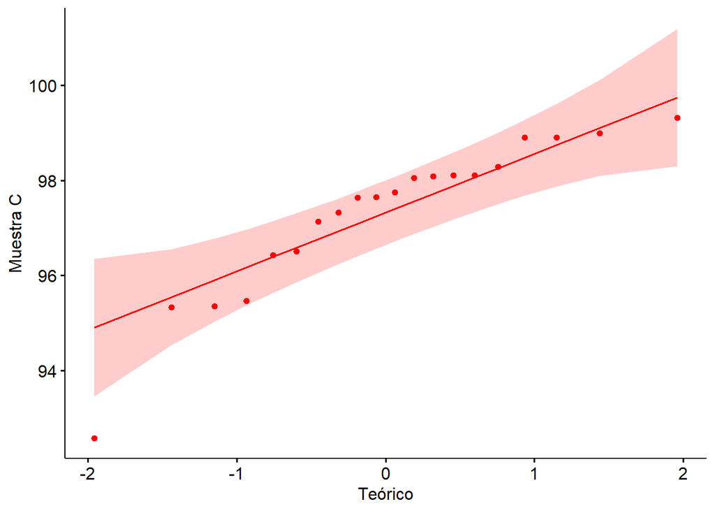

```r
print(g4)
```

Como se puede ver, las muestras de datos difieren de una distribución normal, no obstante, se piensa que no son independientes, pues se menciona que ambas vienen de la misma instancia con iguales características, razón por la cual se piensa que son muestras pareadas. En vista de todo esto se decide utilizar una prueba de Wilcoxon signed‑rank test.

```r
wilcox.test(muestra_A, muestra_C, paired = TRUE, alternative = "two.sided")
```

```
##
##  Wilcoxon signed rank exact test
##
## data:  muestra_A and muestra_C
## V = 130, p-value = 0.3683
## alternative hypothesis: true location shift is not equal to 0
```

El valor p es de 0.36, el cual es mayor al 5% de significancia estándar de la prueba.

Como el p-valor es mayor que 0.05, no se rechaza la hipótesis nula (H₀) al nivel de significancia del 5%, por lo que no hay evidencia suficiente para rechazar la hipótesis nula, por lo que las mejores soluciones encontradas por las versiones A y C del algoritmo cuando las instancias tienen 45 o más nodos no tienen diferencias significativas.

## Pregunta 3: La memorista sospecha que hay diferencias significativas en el tiempo de ejecución entre las versiones del algoritmo cuando las instancias de prueba tienen 70 o más nodos. ¿Los datos respaldan la intuición de la memorista?

Para responder, filtren los datos para tener las instancias con 70 o más nodos y seleccionen las columnas con los tiempos de ejecución registrados (en formato ancho). Usando como semilla el valor 31, obtengan muestras aleatorias independientes de 17, 13 y 15 tiempos registrados por las versiones A, B y C, respectivamente. Realicen un análisis estadístico pertinente (enunciar hipótesis, revisar condiciones, seleccionar pruebas ómnibus y post-hoc según corresponda) para responder la pregunta planteada, utilizando pruebas no paramétricas de ser necesario.

En primer lugar se parte filtrando los datos para tener las instancias con más de 70 nodos de los tres algoritmos.

```r
# Se filtran instancias con 70 o más nodos seleccionando el tiempo de ejecución

datos_filtrados3 <- datos %>%
  filter(n.nodos >= 70) %>%
  select(tiempo.A, tiempo.B, tiempo.C)
```

Posteriormente se determina la semilla como 31 y se escogen aleatoriamente 17, 13 y 15 datos para las muestras A, B y C respectivamente.

```r
set.seed(31)

# Se sobreescriben las 3 muestras
muestra_A <- sample(datos_filtrados3$tiempo.A, 17, replace = TRUE)
muestra_B <- sample(datos_filtrados3$tiempo.B, 13, replace = TRUE)
muestra_C <- sample(datos_filtrados3$tiempo.C, 15, replace = TRUE)
```

## Hipótesis pregunta 3

H_0: Los tiempos para las 3 versiones del algoritmo cuando las instancias tienen 70 o más nodos no tienen diferencias significativas.

H_A: Los tiempos para las 3 versiones del algoritmo cuando las instancias tienen 70 o más nodos tienen diferencias significativas.

Las hipótesis están establecidas, pero primero se necesita corroborar la prueba omnibus que hay que utilizar. Como son menos de 30 datos será complicado aplicar una prueba paramétrica, pero aún así se realizan pruebas de normalidad y se hace un Gráfico Q-Q para consolidar la decisión de la prueba.

```r
shapiro.test(muestra_A)
```

```
##
##  Shapiro-Wilk normality test
##
## data:  muestra_A
## W = 0.88694, p-value = 0.04126
```

```r
shapiro.test(muestra_B)
```

```
##
##  Shapiro-Wilk normality test
##
## data:  muestra_B
## W = 0.89927, p-value = 0.1307
```

```r
shapiro.test(muestra_C)
```

```
##
##  Shapiro-Wilk normality test
##
## data:  muestra_C
## W = 0.9248, p-value = 0.2279
```

Los resultados de las pruebas de normalidad arrojan que las muestras B y C siguen una distribución normal, más la muestra A no sigue una distribución normal. Esto se comprueba gráficamente mediante el uso de un gráfico Q-Q.

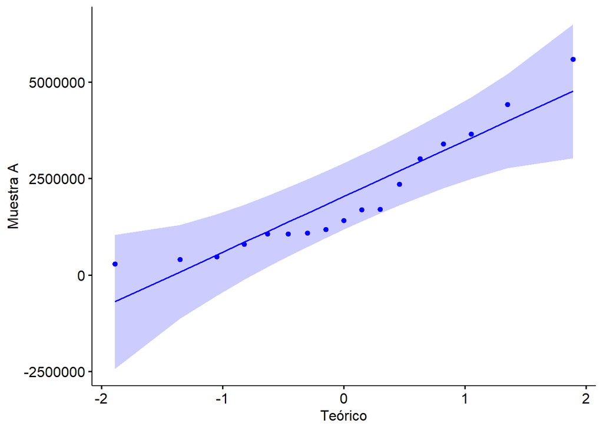

```r
#Gráfico Q-Q para normalidad
g5 <- ggqqplot(data = muestra_A,
                    xlab = "Teórico",
                    ylab = "Muestra A",
                    color = "blue",
                    alpha = 0.7)

g6 <- ggqqplot(data = muestra_B,
                    xlab = "Teórico",
                    ylab = "Muestra B",
                    color = "red",
                    alpha = 0.7)

g7 <- ggqqplot(data = muestra_C,
                    xlab = "Teórico",
                    ylab = "Muestra C",
                    color = "green",
                    alpha = 0.7)
print(g5)
```

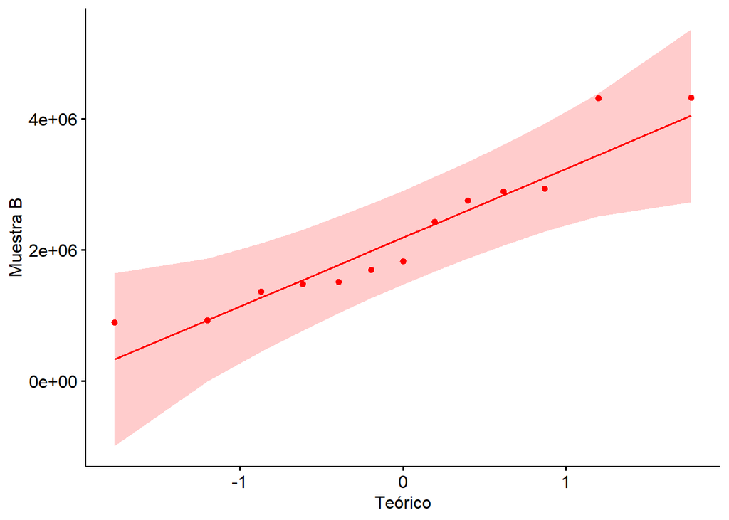

```r
print(g6)
```

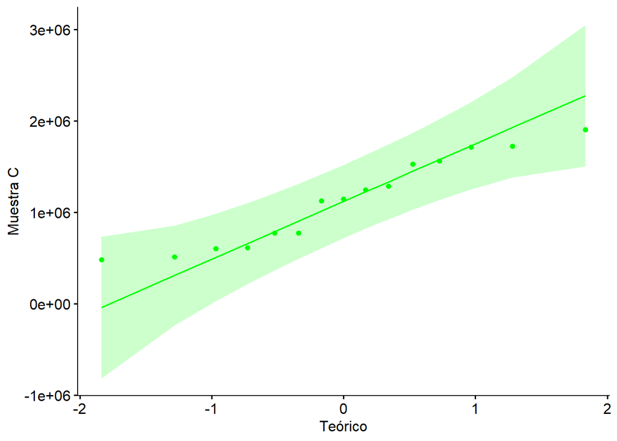

```r
print(g7)
```

Como se puede evidenciar en los gráficos, los datos no se alejan demasiado de una distribución normal para las muestras B y C. Sin embargo, se alejan en el centro de la muestra A, consolidando que no siga una distribución normal. La existencia de 3 grupos independientes (muestra A, muestra B y muestra C) y al menos una muestra no es normal, se decide utilizar la prueba ómnibus no paramétrica Kruskal–Wallis.

Para ello se deben seguir una serie de pasos.

```r
# 1) Preparar dataframe
df <- data.frame(
  val = c(muestra_A, muestra_B, muestra_C),
  grp = factor(rep(c("A","B","C"), times = c(length(muestra_A), length(muestra_B), length(muestra_C))))
)

# 2) Estadísticos descriptivos (mediana + IQR)
df %>% group_by(grp) %>% summarise(n = n(), mediana = median(val), IQR = IQR(val), mean = mean(val), sd = sd(val))
```

```
## # A tibble: 3 × 6
##   grp       n mediana      IQR     mean       sd
##   <fct> <int>   <int>    <dbl>    <dbl>    <dbl>
## 1 A        17 1407557 1949584  1973792. 1535913.
## 2 B        13 1825003 1420794  2257789  1146796.
## 3 C        15 1146021  851910. 1132950.  483912.
```

```r
# 3) Comprobar normalidad (ya se comprobó normalidad) y homogeneidad
leveneTest(val ~ grp, data = df)     # Levene para homogeneidad de varianzas
```

```
## Levene's Test for Homogeneity of Variance (center = median)
##       Df F value  Pr(>F)
## group  2  3.2261 0.04973 *
##       42
## ---
## Signif. codes:  0 '***' 0.001 '**' 0.01 '*' 0.05 '.' 0.1 ' ' 1
```

```r
# 4) Prueba ómnibus no paramétrica: Kruskal-Wallis
kruskal_res <- kruskal.test(val ~ grp, data = df)
kruskal_res
```

```
##
##  Kruskal-Wallis rank sum test
##
## data:  val by grp
## Kruskal-Wallis chi-squared = 6.1464, df = 2, p-value = 0.04627
```

Como el valor de p es de 0.046 aproximadamente, se pasa al paso 5, hacer pruebas post-hoc

```r
# 5) Si Kruskal-Wallis es significativo (p < 0.05) se aplica post-hoc:
pairwise.wilcox.test(df$val, df$grp, p.adjust.method = "holm", exact = FALSE)
```

```
##
##  Pairwise comparisons using Wilcoxon rank sum test with continuity correction
##
## data:  df$val and df$grp
##
##   A     B
## B 0.581 -
## C 0.581 0.017
##
## P value adjustment method: holm
```

Finalmente, se compararon los tiempos de ejecución de las versiones A, B y C en instancias con 70 o más nodos. Debido a que los datos no cumplen normalidad en todos los grupos y las muestras son independientes, se utilizó la prueba de Kruskal–Wallis rank sum test en dplyr tras el filtrado.

El resultado fue significativo (p = 0.04627), por lo que se procedió a comparaciones por pares mediante Wilcoxon rank‑sum test con corrección de p-valores (método Holm).

Las comparaciones mostraron: A vs B: ajuste de p = 0.58, A vs C: ajuste de p = 0.58, y B vs C: ajuste de p = 0.017 (< 0.05) . Por lo tanto, la única diferencia estadísticamente significativa se encuentra entre las versiones B y C, mientras que A no presenta un rendimiento temporal distinto a B ni a C al 5% de significancia.

En conclusión, la intuición de la memorista es parcialmente correcta: sí existen diferencias significativas en tiempos de ejecución, pero no entre A y las otras versiones, sino específicamente entre B y C.

## Pregunta 4. La memorista también sospecha que, al comparar las mismas instancias con iguales características, las mejores soluciones encontradas por las diferentes versiones del algoritmo tienen rendimientos distintos. ¿Estará en lo cierto?

Para responder, filtren los datos para tener las instancias con 70 o más nodos y seleccionen las columnas con los mejores rendimientos registrados. Usando como semilla el valor 71, obtengan una muestra aleatoria de 21 instancias. Realicen un análisis estadístico pertinente (enunciar hipótesis, revisar condiciones, seleccionar pruebas ómnibus y post-hoc según corresponda) para responder la pregunta planteada, utilizando pruebas no paramétricas de ser necesario.

En primer lugar se parte filtrando los datos para tener las instancias con más de 70 nodos de los tres algoritmos.

```r
# Se filtran instancias con 70 o más nodos seleccionando las mejores soluciones

datos_filtrados4 <- datos %>%
  filter(n.nodos >= 70) %>%
  select(mejor.A, mejor.B, mejor.C)
```

Posteriormente se determina la semilla como 71 y se escogen aleatoriamente 21 datos para cada muestra.

```r
set.seed(71)

# Se sobreescriben las 3 muestras
muestra_A <- sample(datos_filtrados4$mejor.A, 21, replace = TRUE)
muestra_B <- sample(datos_filtrados4$mejor.B, 21, replace = TRUE)
muestra_C <- sample(datos_filtrados4$mejor.C, 21, replace = TRUE)
```

## Hipótesis pregunta 4

H_0: Las mejores soluciones para las 3 versiones del algoritmo cuando las instancias tienen 70 o más nodos no tienen diferencias significativas.

H_A: Las mejores soluciones para las 3 versiones del algoritmo cuando las instancias tienen 70 o más nodos tienen diferencias significativas.

Las hipótesis están establecidas, pero primero se necesita corroborar la prueba omnibus que hay que utilizar. Como son menos de 30 datos será complicado aplicar una prueba paramétrica, pero aún así se realizan pruebas de normalidad y se hace un Gráfico Q-Q para consolidar la decisión de la prueba.

```r
shapiro.test(muestra_A)
```

```
##
##  Shapiro-Wilk normality test
##
## data:  muestra_A
## W = 0.96152, p-value = 0.5473
```

```r
shapiro.test(muestra_B)
```

```
##
##  Shapiro-Wilk normality test
##
## data:  muestra_B
## W = 0.95707, p-value = 0.4592
```

```r
shapiro.test(muestra_C)
```

```
##
##  Shapiro-Wilk normality test
##
## data:  muestra_C
## W = 0.95825, p-value = 0.4817
```

Los resultados de las pruebas de normalidad arrojan que las tres muestras siguen una distribución normal. Para evidenciar gráficamente esto se realizan gráficos Q-Q.

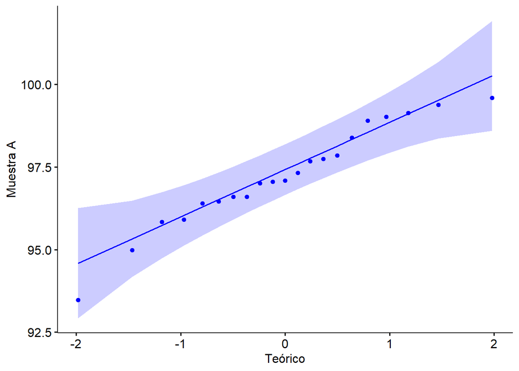

```r
#Gráfico Q-Q para normalidad
g8 <- ggqqplot(data = muestra_A,
                    xlab = "Teórico",
                    ylab = "Muestra A",
                    color = "blue",
                    alpha = 0.7)

g9 <- ggqqplot(data = muestra_B,
                    xlab = "Teórico",
                    ylab = "Muestra B",
                    color = "red",
                    alpha = 0.7)

g10 <- ggqqplot(data = muestra_C,
                    xlab = "Teórico",
                    ylab = "Muestra C",
                    color = "green",
                    alpha = 0.7)
print(g8)
```

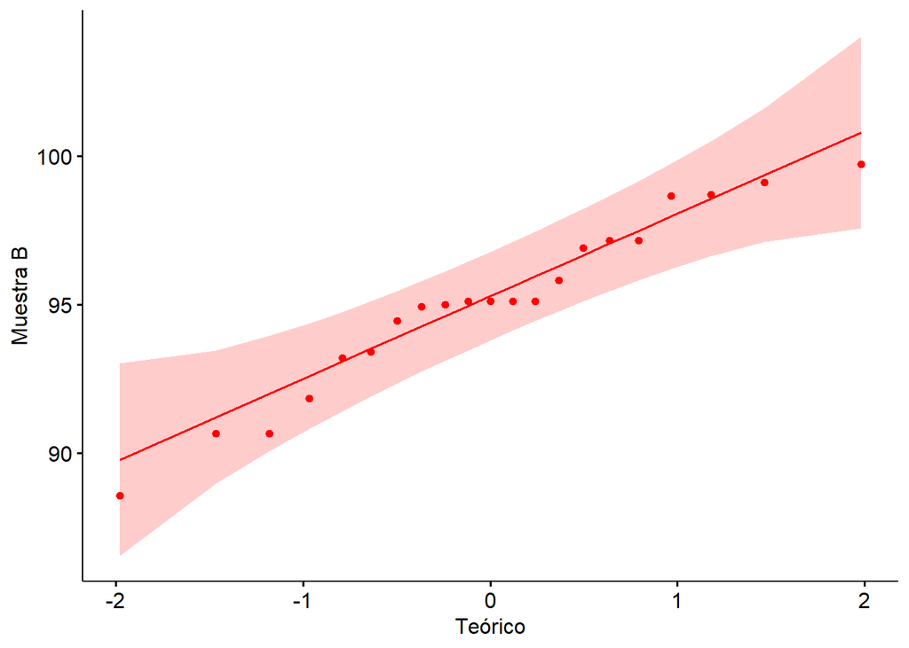

```r
print(g9)
```

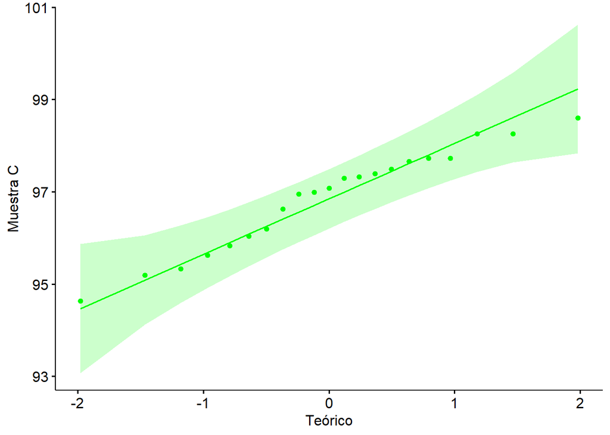

```r
print(g10)
```

Como se puede evidenciar en los gráficos, los datos se asemejan a una distribución normal. La existencia de 3 grupos pareados, pues se menciona que se comparan las mismas instancias con iguales características y que todos sigan una distribución normal hace que se decida utilizar la prueba omnibús de Friedman test para detectar diferencias en los rendimientos de las 3 versiones del algoritmo.

Para ello se arma el data frame y se realiza la prueba.

```r
df <- data.frame(
  val = c(muestra_A, muestra_B, muestra_C),
  grp = factor(rep(c("A","B","C"), each = 21)),
  instancia = factor(rep(1:21, 3))
)

friedman.test(val ~ grp | instancia, data = df)
```

```
##
##  Friedman rank sum test
##
## data:  val and grp and instancia
## Friedman chi-squared = 6.9524, df = 2, p-value = 0.03092
```

El valor p arrojado es significativo, por lo que hay que aplicar pruebas post-hoc

```r
pairwise.wilcox.test(df$val, df$grp,
                     paired = TRUE,
                     p.adjust.method = "holm",
                     exact = FALSE)
```

```
##
##  Pairwise comparisons using Wilcoxon signed rank test with continuity correction
##
## data:  df$val and df$grp
##
##   A    B
## B 0.03 -
## C 0.37 0.11
##
## P value adjustment method: holm
```

En conclusión, se comparó el rendimiento de las mejores soluciones obtenidas por las versiones A, B y C del algoritmo en las mismas instancias con 70 o más nodos, empleando como prueba ómnibus no paramétrica el Friedman test, adecuado para 3 grupos dependientes. Como el ómnibus resultó significativo (p = 0.03), se realizaron comparaciones post-hoc por pares usando el Wilcoxon signed‑rank test con ajuste Holm.

Los p-valores ajustados obtenidos fueron: A vs B = 0.03 (< 0.05), A vs C = 0.37 (> 0.05) y B vs C = 0.11 (> 0.05). Por lo tanto, se detecta una diferencia significativa en el rendimiento solo entre las versiones A y B, mientras que no hay evidencia suficiente para afirmar diferencias de rendimiento entre A y C ni entre B y C al nivel del 5%.

En conclusión, los datos indican que la memorista está parcialmente en lo cierto: sí existen diferencias significativas en las mejores soluciones de algunas versiones, pero la diferencia comprobable estadísticamente se limita al par A vs B. Las demás comparaciones no resultan significativas, y el análisis debe interpretarse en ese alcance específico.